# Risk Factor Analysis

## Outcome Variable

**Outcome Variable:** ever_wasted

## Predictor Variables

**Intervention Variable:** vagbrth

**Adjustment Set:**

- arm
- sex
- W_mage
- meducyrs
- feducyrs
- hhwealth_quart
- W_mhtcm
- W_nrooms
- W_nchldlt5
- brthmon
- W_parity
- impfloor
- impsan
- safeh20
- delta_W_mage
- delta_meducyrs
- delta_feducyrs
- delta_hhwealth_quart
- delta_W_mhtcm
- delta_W_nrooms
- delta_W_nchldlt5
- delta_brthmon
- delta_W_parity
- delta_impfloor
- delta_impsan
- delta_safeh20

## Stratifying Variables

The analysis was stratified on these variable(s):

- agecat
- studyid
- country

## Data Summary

| agecat | studyid | country | vagbrth | ever_wasted | n_cell | n |
| --- | --- | --- | --- | --- | --- | --- |
| 0-24 months (no birth wast) | ki1000108-CMC-V-BCS-2002 | INDIA | 0 | 0 | 17 | 368 |
| 0-24 months (no birth wast) | ki1000108-CMC-V-BCS-2002 | INDIA | 0 | 1 | 8 | 368 |
| 0-24 months (no birth wast) | ki1000108-CMC-V-BCS-2002 | INDIA | 1 | 0 | 185 | 368 |
| 0-24 months (no birth wast) | ki1000108-CMC-V-BCS-2002 | INDIA | 1 | 1 | 158 | 368 |
| 0-24 months (no birth wast) | ki1000108-IRC | INDIA | 0 | 0 | 38 | 409 |
| 0-24 months (no birth wast) | ki1000108-IRC | INDIA | 0 | 1 | 32 | 409 |
| 0-24 months (no birth wast) | ki1000108-IRC | INDIA | 1 | 0 | 158 | 409 |
| 0-24 months (no birth wast) | ki1000108-IRC | INDIA | 1 | 1 | 181 | 409 |
| 0-24 months (no birth wast) | ki1017093b-PROVIDE | BANGLADESH | 0 | 0 | 132 | 687 |
| 0-24 months (no birth wast) | ki1017093b-PROVIDE | BANGLADESH | 0 | 1 | 27 | 687 |
| 0-24 months (no birth wast) | ki1017093b-PROVIDE | BANGLADESH | 1 | 0 | 433 | 687 |
| 0-24 months (no birth wast) | ki1017093b-PROVIDE | BANGLADESH | 1 | 1 | 95 | 687 |
| 0-24 months (no birth wast) | ki1017093c-NIH-Crypto | BANGLADESH | 0 | 0 | 181 | 496 |
| 0-24 months (no birth wast) | ki1017093c-NIH-Crypto | BANGLADESH | 0 | 1 | 21 | 496 |
| 0-24 months (no birth wast) | ki1017093c-NIH-Crypto | BANGLADESH | 1 | 0 | 245 | 496 |
| 0-24 months (no birth wast) | ki1017093c-NIH-Crypto | BANGLADESH | 1 | 1 | 49 | 496 |
| 0-24 months (no birth wast) | ki1066203-TanzaniaChild2 | TANZANIA, UNITED REPUBLIC OF | 0 | 0 | 174 | 2355 |
| 0-24 months (no birth wast) | ki1066203-TanzaniaChild2 | TANZANIA, UNITED REPUBLIC OF | 0 | 1 | 38 | 2355 |
| 0-24 months (no birth wast) | ki1066203-TanzaniaChild2 | TANZANIA, UNITED REPUBLIC OF | 1 | 0 | 1712 | 2355 |
| 0-24 months (no birth wast) | ki1066203-TanzaniaChild2 | TANZANIA, UNITED REPUBLIC OF | 1 | 1 | 431 | 2355 |
| 0-24 months (no birth wast) | ki1119695-PROBIT | BELARUS | 0 | 0 | 1812 | 16877 |
| 0-24 months (no birth wast) | ki1119695-PROBIT | BELARUS | 0 | 1 | 138 | 16877 |
| 0-24 months (no birth wast) | ki1119695-PROBIT | BELARUS | 1 | 0 | 13855 | 16877 |
| 0-24 months (no birth wast) | ki1119695-PROBIT | BELARUS | 1 | 1 | 1072 | 16877 |
| 0-24 months (no birth wast) | ki1126311-ZVITAMBO | ZIMBABWE | 0 | 0 | 1044 | 13510 |
| 0-24 months (no birth wast) | ki1126311-ZVITAMBO | ZIMBABWE | 0 | 1 | 97 | 13510 |
| 0-24 months (no birth wast) | ki1126311-ZVITAMBO | ZIMBABWE | 1 | 0 | 11121 | 13510 |
| 0-24 months (no birth wast) | ki1126311-ZVITAMBO | ZIMBABWE | 1 | 1 | 1248 | 13510 |
| 0-24 months (no birth wast) | kiGH5241-JiVitA-3 | BANGLADESH | 0 | 0 | 2601 | 52806 |
| 0-24 months (no birth wast) | kiGH5241-JiVitA-3 | BANGLADESH | 0 | 1 | 378 | 52806 |

[output cut: 78 more lines]

The following strata were considered:

- agecat: 0-24 months (no birth wast), studyid: ki1000108-CMC-V-BCS-2002, country: INDIA
- agecat: 0-24 months (no birth wast), studyid: ki1000108-IRC, country: INDIA
- agecat: 0-24 months (no birth wast), studyid: ki1017093b-PROVIDE, country: BANGLADESH
- agecat: 0-24 months (no birth wast), studyid: ki1017093c-NIH-Crypto, country: BANGLADESH
- agecat: 0-24 months (no birth wast), studyid: ki1066203-TanzaniaChild2, country: TANZANIA, UNITED REPUBLIC OF
- agecat: 0-24 months (no birth wast), studyid: ki1119695-PROBIT, country: BELARUS
- agecat: 0-24 months (no birth wast), studyid: ki1126311-ZVITAMBO, country: ZIMBABWE
- agecat: 0-24 months (no birth wast), studyid: kiGH5241-JiVitA-3, country: BANGLADESH
- agecat: 0-24 months (no birth wast), studyid: kiGH5241-JiVitA-4, country: BANGLADESH
- agecat: 0-6 months (no birth wast), studyid: ki1000108-CMC-V-BCS-2002, country: INDIA
- agecat: 0-6 months (no birth wast), studyid: ki1000108-IRC, country: INDIA
- agecat: 0-6 months (no birth wast), studyid: ki1017093b-PROVIDE, country: BANGLADESH
- agecat: 0-6 months (no birth wast), studyid: ki1017093c-NIH-Crypto, country: BANGLADESH
- agecat: 0-6 months (no birth wast), studyid: ki1066203-TanzaniaChild2, country: TANZANIA, UNITED REPUBLIC OF
- agecat: 0-6 months (no birth wast), studyid: ki1119695-PROBIT, country: BELARUS
- agecat: 0-6 months (no birth wast), studyid: ki1126311-ZVITAMBO, country: ZIMBABWE
- agecat: 0-6 months (no birth wast), studyid: kiGH5241-JiVitA-3, country: BANGLADESH
- agecat: 0-6 months (no birth wast), studyid: kiGH5241-JiVitA-4, country: BANGLADESH
- agecat: 6-24 months, studyid: ki1000108-CMC-V-BCS-2002, country: INDIA
- agecat: 6-24 months, studyid: ki1000108-IRC, country: INDIA
- agecat: 6-24 months, studyid: ki1017093b-PROVIDE, country: BANGLADESH
- agecat: 6-24 months, studyid: ki1017093c-NIH-Crypto, country: BANGLADESH
- agecat: 6-24 months, studyid: ki1066203-TanzaniaChild2, country: TANZANIA, UNITED REPUBLIC OF
- agecat: 6-24 months, studyid: ki1119695-PROBIT, country: BELARUS
- agecat: 6-24 months, studyid: ki1126311-ZVITAMBO, country: ZIMBABWE
- agecat: 6-24 months, studyid: kiGH5241-JiVitA-3, country: BANGLADESH
- agecat: 6-24 months, studyid: kiGH5241-JiVitA-4, country: BANGLADESH

### Dropped Strata

Some strata were dropped due to rare outcomes:

- agecat: 0-6 months (no birth wast), studyid: ki1017093c-NIH-Crypto, country: BANGLADESH
- agecat: 6-24 months, studyid: ki1000108-CMC-V-BCS-2002, country: INDIA

## Methods Detail

We’re interested in the causal parameters $E[Y_a]$ for all values of $a \in \mathcal{A}$. These parameters represent the mean outcome if, possibly contrary to fact, we intervened to set all units to have $A=a$. Under the randomization and positivity assumptions, these are identified by the statistical parameters $\psi_a=E_W[E_{Y|A,W}(Y|A=a,W)]$. In addition, we’re interested in the mean of $Y$, $E[Y]$ under no intervention (the observed mean). We will estimate these parameters by using SuperLearner to fit the relevant likelihood factors – $E_{Y|A,W}(Y|A=a,W)$ and $p(A=a|W)$, and then updating our likelihood fit using a joint TMLE.

For unadjusted analyses ($W=\{\}$), initial likelihoods were estimated using Lrnr_glm to estimate the simple $E(Y|A)$ and Lrnr_mean to estimate $p(A)$. For adjusted analyses, a small library containing Lrnr_glmnet, Lrnr_xgboost, and Lrnr_mean was used.

Having estimated these parameters, we will then use the delta method to estimate relative risks and attributable risks relative to a prespecified baseline level of $A$.

# Results Detail

## Results Plots

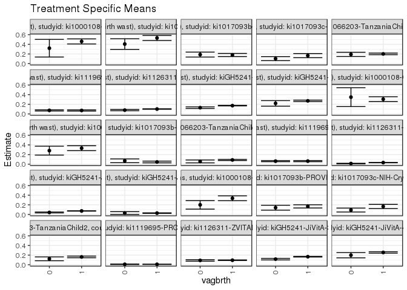

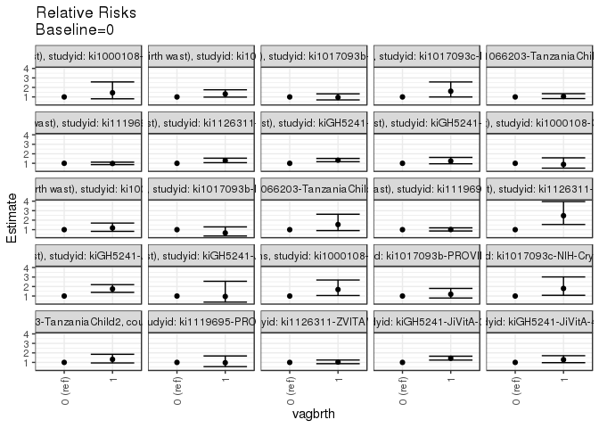

[figure not shown]

[figure not shown]

## Results Table

### Parameter: TSM

| agecat | studyid | country | intervention_level | baseline_level | estimate | ci_lower | ci_upper |
| --- | --- | --- | --- | --- | --- | --- | --- |
| 0-24 months (no birth wast) | ki1000108-CMC-V-BCS-2002 | INDIA | 0 | NA | 0.3200000 | 0.1368958 | 0.5031042 |
| 0-24 months (no birth wast) | ki1000108-CMC-V-BCS-2002 | INDIA | 1 | NA | 0.4606414 | 0.4078197 | 0.5134631 |
| 0-24 months (no birth wast) | ki1000108-IRC | INDIA | 0 | NA | 0.4061825 | 0.2955617 | 0.5168032 |
| 0-24 months (no birth wast) | ki1000108-IRC | INDIA | 1 | NA | 0.5321820 | 0.4791109 | 0.5852530 |
| 0-24 months (no birth wast) | ki1017093b-PROVIDE | BANGLADESH | 0 | NA | 0.1876701 | 0.1361517 | 0.2391886 |
| 0-24 months (no birth wast) | ki1017093b-PROVIDE | BANGLADESH | 1 | NA | 0.1791047 | 0.1469470 | 0.2112624 |
| 0-24 months (no birth wast) | ki1017093c-NIH-Crypto | BANGLADESH | 0 | NA | 0.1038484 | 0.0619980 | 0.1456988 |
| 0-24 months (no birth wast) | ki1017093c-NIH-Crypto | BANGLADESH | 1 | NA | 0.1662492 | 0.1239175 | 0.2085810 |
| 0-24 months (no birth wast) | ki1066203-TanzaniaChild2 | TANZANIA, UNITED REPUBLIC OF | 0 | NA | 0.1917265 | 0.1478852 | 0.2355678 |
| 0-24 months (no birth wast) | ki1066203-TanzaniaChild2 | TANZANIA, UNITED REPUBLIC OF | 1 | NA | 0.2017180 | 0.1847898 | 0.2186461 |
| 0-24 months (no birth wast) | ki1119695-PROBIT | BELARUS | 0 | NA | 0.0730999 | 0.0610200 | 0.0851797 |
| 0-24 months (no birth wast) | ki1119695-PROBIT | BELARUS | 1 | NA | 0.0717397 | 0.0594429 | 0.0840366 |
| 0-24 months (no birth wast) | ki1126311-ZVITAMBO | ZIMBABWE | 0 | NA | 0.0787562 | 0.0649123 | 0.0926001 |
| 0-24 months (no birth wast) | ki1126311-ZVITAMBO | ZIMBABWE | 1 | NA | 0.1009585 | 0.0956620 | 0.1062550 |
| 0-24 months (no birth wast) | kiGH5241-JiVitA-3 | BANGLADESH | 0 | NA | 0.1293225 | 0.1127001 | 0.1459450 |
| 0-24 months (no birth wast) | kiGH5241-JiVitA-3 | BANGLADESH | 1 | NA | 0.1717862 | 0.1663455 | 0.1772270 |
| 0-24 months (no birth wast) | kiGH5241-JiVitA-4 | BANGLADESH | 0 | NA | 0.2188649 | 0.1614973 | 0.2762325 |
| 0-24 months (no birth wast) | kiGH5241-JiVitA-4 | BANGLADESH | 1 | NA | 0.2711206 | 0.2555962 | 0.2866450 |
| 0-6 months (no birth wast) | ki1000108-CMC-V-BCS-2002 | INDIA | 0 | NA | 0.3478261 | 0.1529008 | 0.5427514 |
| 0-6 months (no birth wast) | ki1000108-CMC-V-BCS-2002 | INDIA | 1 | NA | 0.3058104 | 0.2558000 | 0.3558208 |
| 0-6 months (no birth wast) | ki1000108-IRC | INDIA | 0 | NA | 0.2814740 | 0.1893049 | 0.3736431 |
| 0-6 months (no birth wast) | ki1000108-IRC | INDIA | 1 | NA | 0.3322206 | 0.2810150 | 0.3834263 |
| 0-6 months (no birth wast) | ki1017093b-PROVIDE | BANGLADESH | 0 | NA | 0.0703114 | 0.0311603 | 0.1094624 |
| 0-6 months (no birth wast) | ki1017093b-PROVIDE | BANGLADESH | 1 | NA | 0.0461524 | 0.0281939 | 0.0641108 |
| 0-6 months (no birth wast) | ki1066203-TanzaniaChild2 | TANZANIA, UNITED REPUBLIC OF | 0 | NA | 0.0574885 | 0.0278109 | 0.0871662 |
| 0-6 months (no birth wast) | ki1066203-TanzaniaChild2 | TANZANIA, UNITED REPUBLIC OF | 1 | NA | 0.0884980 | 0.0764594 | 0.1005366 |
| 0-6 months (no birth wast) | ki1119695-PROBIT | BELARUS | 0 | NA | 0.0633237 | 0.0518287 | 0.0748187 |
| 0-6 months (no birth wast) | ki1119695-PROBIT | BELARUS | 1 | NA | 0.0640835 | 0.0523442 | 0.0758227 |
| 0-6 months (no birth wast) | ki1126311-ZVITAMBO | ZIMBABWE | 0 | NA | 0.0134044 | 0.0072390 | 0.0195697 |
| 0-6 months (no birth wast) | ki1126311-ZVITAMBO | ZIMBABWE | 1 | NA | 0.0331255 | 0.0299422 | 0.0363089 |
| 0-6 months (no birth wast) | kiGH5241-JiVitA-3 | BANGLADESH | 0 | NA | 0.0418367 | 0.0322776 | 0.0513959 |
| 0-6 months (no birth wast) | kiGH5241-JiVitA-3 | BANGLADESH | 1 | NA | 0.0730974 | 0.0693291 | 0.0768658 |
| 0-6 months (no birth wast) | kiGH5241-JiVitA-4 | BANGLADESH | 0 | NA | 0.0299103 | 0.0013070 | 0.0585135 |
| 0-6 months (no birth wast) | kiGH5241-JiVitA-4 | BANGLADESH | 1 | NA | 0.0285785 | 0.0232511 | 0.0339058 |
| 6-24 months | ki1000108-IRC | INDIA | 0 | NA | 0.1998782 | 0.1112522 | 0.2885041 |
| 6-24 months | ki1000108-IRC | INDIA | 1 | NA | 0.3365309 | 0.2864690 | 0.3865928 |
| 6-24 months | ki1017093b-PROVIDE | BANGLADESH | 0 | NA | 0.1409647 | 0.0898047 | 0.1921247 |
| 6-24 months | ki1017093b-PROVIDE | BANGLADESH | 1 | NA | 0.1679793 | 0.1347061 | 0.2012525 |
| 6-24 months | ki1017093c-NIH-Crypto | BANGLADESH | 0 | NA | 0.0922797 | 0.0514495 | 0.1331099 |
| 6-24 months | ki1017093c-NIH-Crypto | BANGLADESH | 1 | NA | 0.1660429 | 0.1223088 | 0.2097771 |
| 6-24 months | ki1066203-TanzaniaChild2 | TANZANIA, UNITED REPUBLIC OF | 0 | NA | 0.1233356 | 0.0835567 | 0.1631145 |
| 6-24 months | ki1066203-TanzaniaChild2 | TANZANIA, UNITED REPUBLIC OF | 1 | NA | 0.1629419 | 0.1459739 | 0.1799100 |
| 6-24 months | ki1119695-PROBIT | BELARUS | 0 | NA | 0.0102369 | 0.0053237 | 0.0151502 |
| 6-24 months | ki1119695-PROBIT | BELARUS | 1 | NA | 0.0099004 | 0.0068606 | 0.0129402 |
| 6-24 months | ki1126311-ZVITAMBO | ZIMBABWE | 0 | NA | 0.0905875 | 0.0747995 | 0.1063755 |
| 6-24 months | ki1126311-ZVITAMBO | ZIMBABWE | 1 | NA | 0.0943100 | 0.0885186 | 0.1001013 |
| 6-24 months | kiGH5241-JiVitA-3 | BANGLADESH | 0 | NA | 0.1166031 | 0.1003657 | 0.1328404 |
| 6-24 months | kiGH5241-JiVitA-3 | BANGLADESH | 1 | NA | 0.1672483 | 0.1609073 | 0.1735893 |
| 6-24 months | kiGH5241-JiVitA-4 | BANGLADESH | 0 | NA | 0.1987358 | 0.1438776 | 0.2535939 |
| 6-24 months | kiGH5241-JiVitA-4 | BANGLADESH | 1 | NA | 0.2558281 | 0.2406554 | 0.2710008 |

### Parameter: E(Y)

| agecat | studyid | country | intervention_level | baseline_level | estimate | ci_lower | ci_upper |
| --- | --- | --- | --- | --- | --- | --- | --- |
| 0-24 months (no birth wast) | ki1000108-CMC-V-BCS-2002 | INDIA | NA | NA | 0.4510870 | 0.4001777 | 0.5019962 |
| 0-24 months (no birth wast) | ki1000108-IRC | INDIA | NA | NA | 0.5207824 | 0.4723080 | 0.5692568 |
| 0-24 months (no birth wast) | ki1017093b-PROVIDE | BANGLADESH | NA | NA | 0.1775837 | 0.1489858 | 0.2061816 |
| 0-24 months (no birth wast) | ki1017093c-NIH-Crypto | BANGLADESH | NA | NA | 0.1411290 | 0.1104588 | 0.1717993 |
| 0-24 months (no birth wast) | ki1066203-TanzaniaChild2 | TANZANIA, UNITED REPUBLIC OF | NA | NA | 0.1991507 | 0.1830179 | 0.2152836 |
| 0-24 months (no birth wast) | ki1119695-PROBIT | BELARUS | NA | NA | 0.0716952 | 0.0597165 | 0.0836739 |
| 0-24 months (no birth wast) | ki1126311-ZVITAMBO | ZIMBABWE | NA | NA | 0.0995559 | 0.0945070 | 0.1046048 |
| 0-24 months (no birth wast) | kiGH5241-JiVitA-3 | BANGLADESH | NA | NA | 0.1696398 | 0.1643108 | 0.1749689 |
| 0-24 months (no birth wast) | kiGH5241-JiVitA-4 | BANGLADESH | NA | NA | 0.2670227 | 0.2519875 | 0.2820579 |
| 0-6 months (no birth wast) | ki1000108-CMC-V-BCS-2002 | INDIA | NA | NA | 0.3085714 | 0.2601110 | 0.3570318 |
| 0-6 months (no birth wast) | ki1000108-IRC | INDIA | NA | NA | 0.3410256 | 0.2939169 | 0.3881343 |
| 0-6 months (no birth wast) | ki1017093b-PROVIDE | BANGLADESH | NA | NA | 0.0527086 | 0.0359384 | 0.0694789 |
| 0-6 months (no birth wast) | ki1066203-TanzaniaChild2 | TANZANIA, UNITED REPUBLIC OF | NA | NA | 0.0860673 | 0.0747182 | 0.0974164 |
| 0-6 months (no birth wast) | ki1119695-PROBIT | BELARUS | NA | NA | 0.0637570 | 0.0524446 | 0.0750694 |
| 0-6 months (no birth wast) | ki1126311-ZVITAMBO | ZIMBABWE | NA | NA | 0.0320731 | 0.0290730 | 0.0350731 |
| 0-6 months (no birth wast) | kiGH5241-JiVitA-3 | BANGLADESH | NA | NA | 0.0717945 | 0.0681352 | 0.0754538 |
| 0-6 months (no birth wast) | kiGH5241-JiVitA-4 | BANGLADESH | NA | NA | 0.0287671 | 0.0234680 | 0.0340662 |
| 6-24 months | ki1000108-IRC | INDIA | NA | NA | 0.3097561 | 0.2649438 | 0.3545684 |
| 6-24 months | ki1017093b-PROVIDE | BANGLADESH | NA | NA | 0.1609756 | 0.1319065 | 0.1900447 |
| 6-24 months | ki1017093c-NIH-Crypto | BANGLADESH | NA | NA | 0.1355932 | 0.1046749 | 0.1665115 |
| 6-24 months | ki1066203-TanzaniaChild2 | TANZANIA, UNITED REPUBLIC OF | NA | NA | 0.1608216 | 0.1447012 | 0.1769421 |
| 6-24 months | ki1119695-PROBIT | BELARUS | NA | NA | 0.0100615 | 0.0072668 | 0.0128561 |
| 6-24 months | ki1126311-ZVITAMBO | ZIMBABWE | NA | NA | 0.0936351 | 0.0880903 | 0.0991799 |
| 6-24 months | kiGH5241-JiVitA-3 | BANGLADESH | NA | NA | 0.1640464 | 0.1578959 | 0.1701968 |
| 6-24 months | kiGH5241-JiVitA-4 | BANGLADESH | NA | NA | 0.2517203 | 0.2369063 | 0.2665343 |

### Parameter: RR

| agecat | studyid | country | intervention_level | baseline_level | estimate | ci_lower | ci_upper |
| --- | --- | --- | --- | --- | --- | --- | --- |
| 0-24 months (no birth wast) | ki1000108-CMC-V-BCS-2002 | INDIA | 0 | 0 | 1.0000000 | 1.0000000 | 1.000000 |
| 0-24 months (no birth wast) | ki1000108-CMC-V-BCS-2002 | INDIA | 1 | 0 | 1.4395044 | 0.8030978 | 2.580225 |
| 0-24 months (no birth wast) | ki1000108-IRC | INDIA | 0 | 0 | 1.0000000 | 1.0000000 | 1.000000 |
| 0-24 months (no birth wast) | ki1000108-IRC | INDIA | 1 | 0 | 1.3102042 | 0.9805424 | 1.750699 |
| 0-24 months (no birth wast) | ki1017093b-PROVIDE | BANGLADESH | 0 | 0 | 1.0000000 | 1.0000000 | 1.000000 |
| 0-24 months (no birth wast) | ki1017093b-PROVIDE | BANGLADESH | 1 | 0 | 0.9543592 | 0.6880238 | 1.323794 |
| 0-24 months (no birth wast) | ki1017093c-NIH-Crypto | BANGLADESH | 0 | 0 | 1.0000000 | 1.0000000 | 1.000000 |
| 0-24 months (no birth wast) | ki1017093c-NIH-Crypto | BANGLADESH | 1 | 0 | 1.6008839 | 0.9949703 | 2.575785 |
| 0-24 months (no birth wast) | ki1066203-TanzaniaChild2 | TANZANIA, UNITED REPUBLIC OF | 0 | 0 | 1.0000000 | 1.0000000 | 1.000000 |
| 0-24 months (no birth wast) | ki1066203-TanzaniaChild2 | TANZANIA, UNITED REPUBLIC OF | 1 | 0 | 1.0521132 | 0.8247662 | 1.342128 |
| 0-24 months (no birth wast) | ki1119695-PROBIT | BELARUS | 0 | 0 | 1.0000000 | 1.0000000 | 1.000000 |
| 0-24 months (no birth wast) | ki1119695-PROBIT | BELARUS | 1 | 0 | 0.9813937 | 0.8608363 | 1.118835 |
| 0-24 months (no birth wast) | ki1126311-ZVITAMBO | ZIMBABWE | 0 | 0 | 1.0000000 | 1.0000000 | 1.000000 |
| 0-24 months (no birth wast) | ki1126311-ZVITAMBO | ZIMBABWE | 1 | 0 | 1.2819114 | 1.0672401 | 1.539763 |
| 0-24 months (no birth wast) | kiGH5241-JiVitA-3 | BANGLADESH | 0 | 0 | 1.0000000 | 1.0000000 | 1.000000 |
| 0-24 months (no birth wast) | kiGH5241-JiVitA-3 | BANGLADESH | 1 | 0 | 1.3283554 | 1.1661506 | 1.513122 |
| 0-24 months (no birth wast) | kiGH5241-JiVitA-4 | BANGLADESH | 0 | 0 | 1.0000000 | 1.0000000 | 1.000000 |
| 0-24 months (no birth wast) | kiGH5241-JiVitA-4 | BANGLADESH | 1 | 0 | 1.2387576 | 0.9467785 | 1.620781 |
| 0-6 months (no birth wast) | ki1000108-CMC-V-BCS-2002 | INDIA | 0 | 0 | 1.0000000 | 1.0000000 | 1.000000 |
| 0-6 months (no birth wast) | ki1000108-CMC-V-BCS-2002 | INDIA | 1 | 0 | 0.8792049 | 0.4904064 | 1.576246 |
| 0-6 months (no birth wast) | ki1000108-IRC | INDIA | 0 | 0 | 1.0000000 | 1.0000000 | 1.000000 |
| 0-6 months (no birth wast) | ki1000108-IRC | INDIA | 1 | 0 | 1.1802891 | 0.8225248 | 1.693666 |
| 0-6 months (no birth wast) | ki1017093b-PROVIDE | BANGLADESH | 0 | 0 | 1.0000000 | 1.0000000 | 1.000000 |
| 0-6 months (no birth wast) | ki1017093b-PROVIDE | BANGLADESH | 1 | 0 | 0.6564000 | 0.3334028 | 1.292313 |
| 0-6 months (no birth wast) | ki1066203-TanzaniaChild2 | TANZANIA, UNITED REPUBLIC OF | 0 | 0 | 1.0000000 | 1.0000000 | 1.000000 |
| 0-6 months (no birth wast) | ki1066203-TanzaniaChild2 | TANZANIA, UNITED REPUBLIC OF | 1 | 0 | 1.5394025 | 0.9028810 | 2.624665 |
| 0-6 months (no birth wast) | ki1119695-PROBIT | BELARUS | 0 | 0 | 1.0000000 | 1.0000000 | 1.000000 |
| 0-6 months (no birth wast) | ki1119695-PROBIT | BELARUS | 1 | 0 | 1.0119979 | 0.8599703 | 1.190901 |
| 0-6 months (no birth wast) | ki1126311-ZVITAMBO | ZIMBABWE | 0 | 0 | 1.0000000 | 1.0000000 | 1.000000 |
| 0-6 months (no birth wast) | ki1126311-ZVITAMBO | ZIMBABWE | 1 | 0 | 2.4712507 | 1.5448712 | 3.953132 |
| 0-6 months (no birth wast) | kiGH5241-JiVitA-3 | BANGLADESH | 0 | 0 | 1.0000000 | 1.0000000 | 1.000000 |
| 0-6 months (no birth wast) | kiGH5241-JiVitA-3 | BANGLADESH | 1 | 0 | 1.7472058 | 1.3877392 | 2.199785 |
| 0-6 months (no birth wast) | kiGH5241-JiVitA-4 | BANGLADESH | 0 | 0 | 1.0000000 | 1.0000000 | 1.000000 |
| 0-6 months (no birth wast) | kiGH5241-JiVitA-4 | BANGLADESH | 1 | 0 | 0.9554740 | 0.3579310 | 2.550577 |
| 6-24 months | ki1000108-IRC | INDIA | 0 | 0 | 1.0000000 | 1.0000000 | 1.000000 |
| 6-24 months | ki1000108-IRC | INDIA | 1 | 0 | 1.6836799 | 1.0553414 | 2.686124 |
| 6-24 months | ki1017093b-PROVIDE | BANGLADESH | 0 | 0 | 1.0000000 | 1.0000000 | 1.000000 |
| 6-24 months | ki1017093b-PROVIDE | BANGLADESH | 1 | 0 | 1.1916411 | 0.7886965 | 1.800450 |
| 6-24 months | ki1017093c-NIH-Crypto | BANGLADESH | 0 | 0 | 1.0000000 | 1.0000000 | 1.000000 |
| 6-24 months | ki1017093c-NIH-Crypto | BANGLADESH | 1 | 0 | 1.7993444 | 1.0754133 | 3.010601 |
| 6-24 months | ki1066203-TanzaniaChild2 | TANZANIA, UNITED REPUBLIC OF | 0 | 0 | 1.0000000 | 1.0000000 | 1.000000 |
| 6-24 months | ki1066203-TanzaniaChild2 | TANZANIA, UNITED REPUBLIC OF | 1 | 0 | 1.3211265 | 0.9417916 | 1.853250 |
| 6-24 months | ki1119695-PROBIT | BELARUS | 0 | 0 | 1.0000000 | 1.0000000 | 1.000000 |
| 6-24 months | ki1119695-PROBIT | BELARUS | 1 | 0 | 0.9671253 | 0.5571892 | 1.678660 |
| 6-24 months | ki1126311-ZVITAMBO | ZIMBABWE | 0 | 0 | 1.0000000 | 1.0000000 | 1.000000 |
| 6-24 months | ki1126311-ZVITAMBO | ZIMBABWE | 1 | 0 | 1.0410926 | 0.8658133 | 1.251856 |
| 6-24 months | kiGH5241-JiVitA-3 | BANGLADESH | 0 | 0 | 1.0000000 | 1.0000000 | 1.000000 |
| 6-24 months | kiGH5241-JiVitA-3 | BANGLADESH | 1 | 0 | 1.4343386 | 1.2446137 | 1.652985 |
| 6-24 months | kiGH5241-JiVitA-4 | BANGLADESH | 0 | 0 | 1.0000000 | 1.0000000 | 1.000000 |
| 6-24 months | kiGH5241-JiVitA-4 | BANGLADESH | 1 | 0 | 1.2872775 | 0.9720347 | 1.704758 |

### Parameter: PAR

| agecat | studyid | country | intervention_level | baseline_level | estimate | ci_lower | ci_upper |
| --- | --- | --- | --- | --- | --- | --- | --- |
| 0-24 months (no birth wast) | ki1000108-CMC-V-BCS-2002 | INDIA | 0 | NA | 0.1310870 | -0.0465745 | 0.3087484 |
| 0-24 months (no birth wast) | ki1000108-IRC | INDIA | 0 | NA | 0.1145999 | 0.0137445 | 0.2154554 |
| 0-24 months (no birth wast) | ki1017093b-PROVIDE | BANGLADESH | 0 | NA | -0.0100864 | -0.0558418 | 0.0356689 |
| 0-24 months (no birth wast) | ki1017093c-NIH-Crypto | BANGLADESH | 0 | NA | 0.0372806 | 0.0019199 | 0.0726413 |
| 0-24 months (no birth wast) | ki1066203-TanzaniaChild2 | TANZANIA, UNITED REPUBLIC OF | 0 | NA | 0.0074243 | -0.0348822 | 0.0497307 |
| 0-24 months (no birth wast) | ki1119695-PROBIT | BELARUS | 0 | NA | -0.0014046 | -0.0098033 | 0.0069940 |
| 0-24 months (no birth wast) | ki1126311-ZVITAMBO | ZIMBABWE | 0 | NA | 0.0207997 | 0.0073379 | 0.0342614 |
| 0-24 months (no birth wast) | kiGH5241-JiVitA-3 | BANGLADESH | 0 | NA | 0.0403173 | 0.0240868 | 0.0565478 |
| 0-24 months (no birth wast) | kiGH5241-JiVitA-4 | BANGLADESH | 0 | NA | 0.0481578 | -0.0065191 | 0.1028347 |
| 0-6 months (no birth wast) | ki1000108-CMC-V-BCS-2002 | INDIA | 0 | NA | -0.0392547 | -0.2272721 | 0.1487628 |
| 0-6 months (no birth wast) | ki1000108-IRC | INDIA | 0 | NA | 0.0595517 | -0.0250763 | 0.1441796 |
| 0-6 months (no birth wast) | ki1017093b-PROVIDE | BANGLADESH | 0 | NA | -0.0176027 | -0.0503002 | 0.0150948 |
| 0-6 months (no birth wast) | ki1066203-TanzaniaChild2 | TANZANIA, UNITED REPUBLIC OF | 0 | NA | 0.0285788 | -0.0003676 | 0.0575252 |
| 0-6 months (no birth wast) | ki1119695-PROBIT | BELARUS | 0 | NA | 0.0004333 | -0.0087472 | 0.0096137 |
| 0-6 months (no birth wast) | ki1126311-ZVITAMBO | ZIMBABWE | 0 | NA | 0.0186687 | 0.0124214 | 0.0249160 |
| 0-6 months (no birth wast) | kiGH5241-JiVitA-3 | BANGLADESH | 0 | NA | 0.0299577 | 0.0205750 | 0.0393405 |
| 0-6 months (no birth wast) | kiGH5241-JiVitA-4 | BANGLADESH | 0 | NA | -0.0011431 | -0.0281548 | 0.0258685 |
| 6-24 months | ki1000108-IRC | INDIA | 0 | NA | 0.1098779 | 0.0255893 | 0.1941665 |
| 6-24 months | ki1017093b-PROVIDE | BANGLADESH | 0 | NA | 0.0200109 | -0.0262975 | 0.0663194 |
| 6-24 months | ki1017093c-NIH-Crypto | BANGLADESH | 0 | NA | 0.0433135 | 0.0079341 | 0.0786930 |
| 6-24 months | ki1066203-TanzaniaChild2 | TANZANIA, UNITED REPUBLIC OF | 0 | NA | 0.0374860 | -0.0010385 | 0.0760106 |
| 6-24 months | ki1119695-PROBIT | BELARUS | 0 | NA | -0.0001755 | -0.0051506 | 0.0047996 |
| 6-24 months | ki1126311-ZVITAMBO | ZIMBABWE | 0 | NA | 0.0030476 | -0.0121938 | 0.0182890 |
| 6-24 months | kiGH5241-JiVitA-3 | BANGLADESH | 0 | NA | 0.0474433 | 0.0315384 | 0.0633482 |
| 6-24 months | kiGH5241-JiVitA-4 | BANGLADESH | 0 | NA | 0.0529845 | 0.0010487 | 0.1049203 |

### Parameter: PAF

| agecat | studyid | country | intervention_level | baseline_level | estimate | ci_lower | ci_upper |
| --- | --- | --- | --- | --- | --- | --- | --- |
| 0-24 months (no birth wast) | ki1000108-CMC-V-BCS-2002 | INDIA | 0 | NA | 0.2906024 | -0.2363609 | 0.5929627 |
| 0-24 months (no birth wast) | ki1000108-IRC | INDIA | 0 | NA | 0.2200534 | -0.0003946 | 0.3919232 |
| 0-24 months (no birth wast) | ki1017093b-PROVIDE | BANGLADESH | 0 | NA | -0.0567982 | -0.3499309 | 0.1726817 |
| 0-24 months (no birth wast) | ki1017093c-NIH-Crypto | BANGLADESH | 0 | NA | 0.2641599 | -0.0271792 | 0.4728665 |
| 0-24 months (no birth wast) | ki1066203-TanzaniaChild2 | TANZANIA, UNITED REPUBLIC OF | 0 | NA | 0.0372796 | -0.2000893 | 0.2276987 |
| 0-24 months (no birth wast) | ki1119695-PROBIT | BELARUS | 0 | NA | -0.0195919 | -0.1450186 | 0.0920954 |
| 0-24 months (no birth wast) | ki1126311-ZVITAMBO | ZIMBABWE | 0 | NA | 0.2089244 | 0.0623648 | 0.3325756 |
| 0-24 months (no birth wast) | kiGH5241-JiVitA-3 | BANGLADESH | 0 | NA | 0.2376642 | 0.1361549 | 0.3272453 |
| 0-24 months (no birth wast) | kiGH5241-JiVitA-4 | BANGLADESH | 0 | NA | 0.1803509 | -0.0531813 | 0.3620997 |
| 0-6 months (no birth wast) | ki1000108-CMC-V-BCS-2002 | INDIA | 0 | NA | -0.1272142 | -0.9353750 | 0.3434803 |
| 0-6 months (no birth wast) | ki1000108-IRC | INDIA | 0 | NA | 0.1746252 | -0.1128337 | 0.3878299 |
| 0-6 months (no birth wast) | ki1017093b-PROVIDE | BANGLADESH | 0 | NA | -0.3339629 | -1.1100652 | 0.1566815 |
| 0-6 months (no birth wast) | ki1066203-TanzaniaChild2 | TANZANIA, UNITED REPUBLIC OF | 0 | NA | 0.3320516 | -0.1003704 | 0.5945410 |
| 0-6 months (no birth wast) | ki1119695-PROBIT | BELARUS | 0 | NA | 0.0067953 | -0.1476238 | 0.1404366 |
| 0-6 months (no birth wast) | ki1126311-ZVITAMBO | ZIMBABWE | 0 | NA | 0.5820677 | 0.3451073 | 0.7332886 |
| 0-6 months (no birth wast) | kiGH5241-JiVitA-3 | BANGLADESH | 0 | NA | 0.4172707 | 0.2725033 | 0.5332302 |
| 0-6 months (no birth wast) | kiGH5241-JiVitA-4 | BANGLADESH | 0 | NA | -0.0397377 | -1.5615104 | 0.5779621 |
| 6-24 months | ki1000108-IRC | INDIA | 0 | NA | 0.3547239 | 0.0219194 | 0.5742874 |
| 6-24 months | ki1017093b-PROVIDE | BANGLADESH | 0 | NA | 0.1243104 | -0.2131431 | 0.3678962 |
| 6-24 months | ki1017093c-NIH-Crypto | BANGLADESH | 0 | NA | 0.3194373 | 0.0130389 | 0.5307155 |
| 6-24 months | ki1066203-TanzaniaChild2 | TANZANIA, UNITED REPUBLIC OF | 0 | NA | 0.2330908 | -0.0454833 | 0.4374375 |
| 6-24 months | ki1119695-PROBIT | BELARUS | 0 | NA | -0.0174403 | -0.6565728 | 0.3751046 |
| 6-24 months | ki1126311-ZVITAMBO | ZIMBABWE | 0 | NA | 0.0325476 | -0.1445490 | 0.1822419 |
| 6-24 months | kiGH5241-JiVitA-3 | BANGLADESH | 0 | NA | 0.2892066 | 0.1863629 | 0.3790508 |
| 6-24 months | kiGH5241-JiVitA-4 | BANGLADESH | 0 | NA | 0.2104898 | -0.0267518 | 0.3929142 |